# SOM analysis for Hungerford

##### Look at correlations again after dropping variables

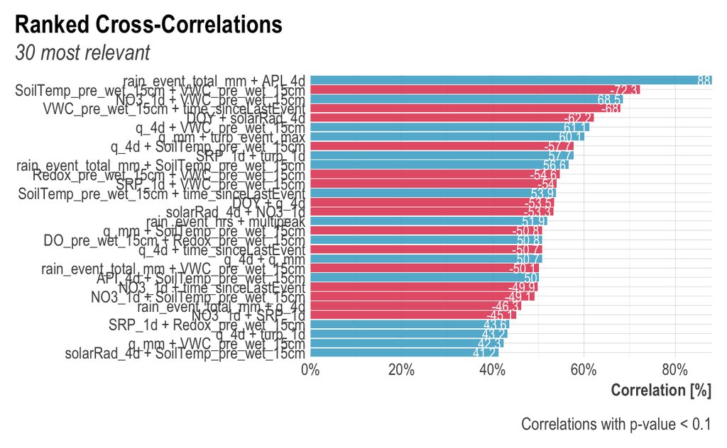

#### Self-organizing map (SOM)

##### Prepare data & set up grid/lattice dimensions

We’re only using complete observations/rows (no NAs in any columns)  
According to the heuristic rule from Vesanto 2000, number of grid elements/grid size/nodes = 5 * sqrt(n)  
To determine the the shape of the grid (ratio of columns to rows), we use the ratio of the first two eigen values of the input data set as recommended by Park et al. 2006

```
## [1] No. of complete observations: 49 out of 76 observations
```

```
## [1] No. of Vesanto nodes: 35
```

```
## [1] Ratio of columns to rows: 1.8
```

##### Run SOM for a suite of grid/lattice configurations, # of nodes, and # of clusters

Code courtesy of Kristen Underwood (hidden)

```
## [1] Topology: hexagonal
```

```
## [1] Data normalization method used: L2norm
```

```
## [1] Weighting method used: noPCA
```

```
## [1] No. of iterations: 1000
```

```
## [1] alphaCrs used: 0.05
```

```
## [1] alphaFin used: 1000
```

##### Choose the best SOM run based on non-parametric F-stat and quantization error

We want to maximize npF (ratio of b/w cluster variance )

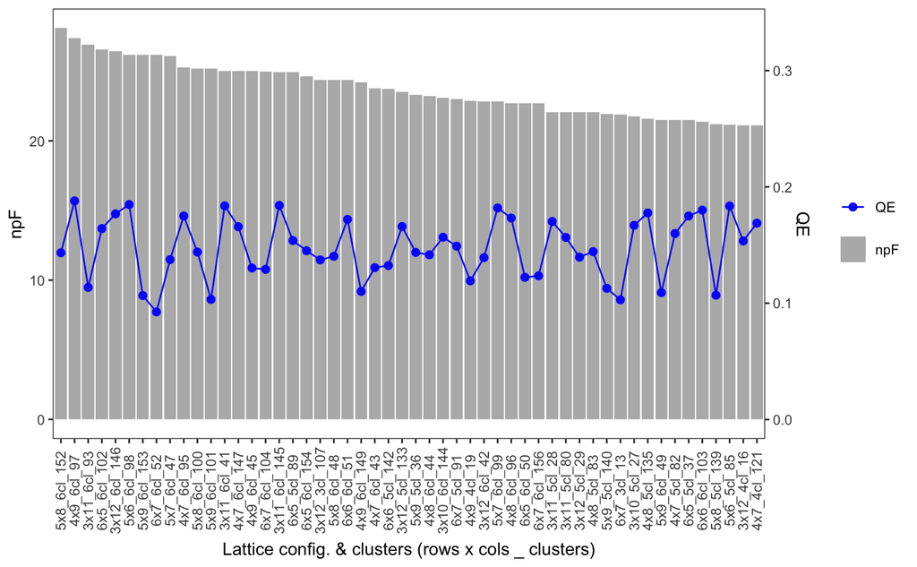

##### Examine the reps of the best run and choose the best to use

```
## [1] These were the top 2 runs:
```

| Run | rows | cols | Nodes | Clusters | npF | QE |
| --- | --- | --- | --- | --- | --- | --- |
| 52 | 6 | 7 | 42 | 6 | 26.19821 | 0.092397 |
| 101 | 5 | 9 | 45 | 6 | 25.20067 | 0.103139 |

```
## [1] The script chose:
```

| Run | rows | cols | Nodes | Clusters | npF | QE |
| --- | --- | --- | --- | --- | --- | --- |
| 52 | 6 | 7 | 42 | 6 | 26.19821 | 0.092397 |

To examine this run in greater detail (e.g., component planes), see the ‘X_SOMplots_site_ … .pdf’

##### Examine boxplots of independent variables by cluster

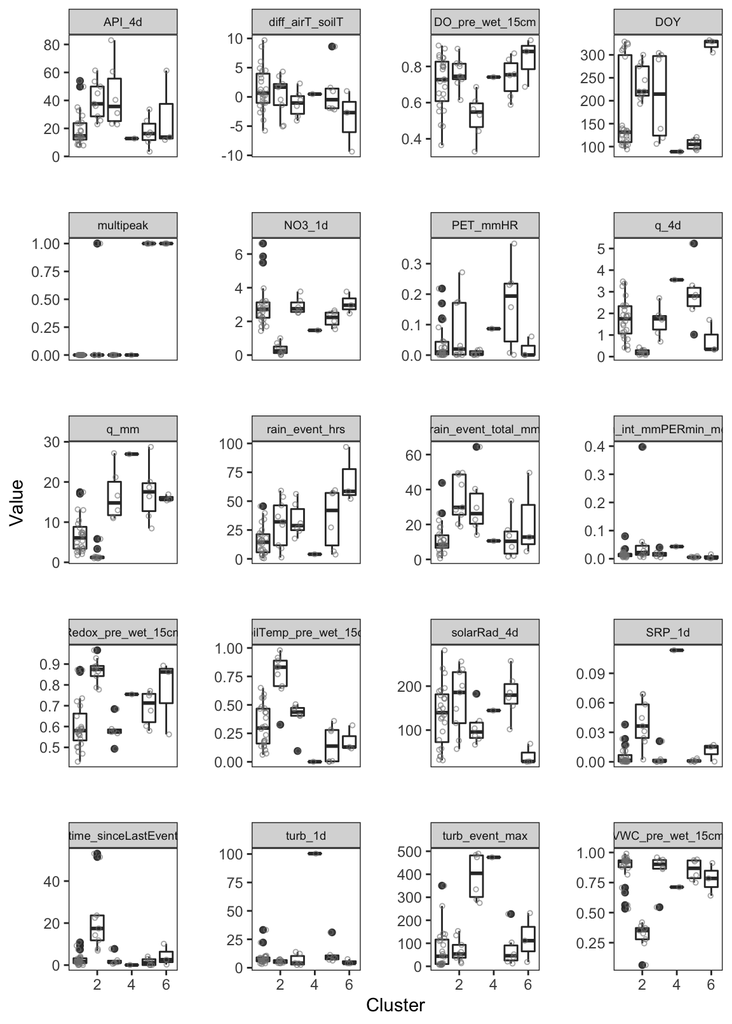

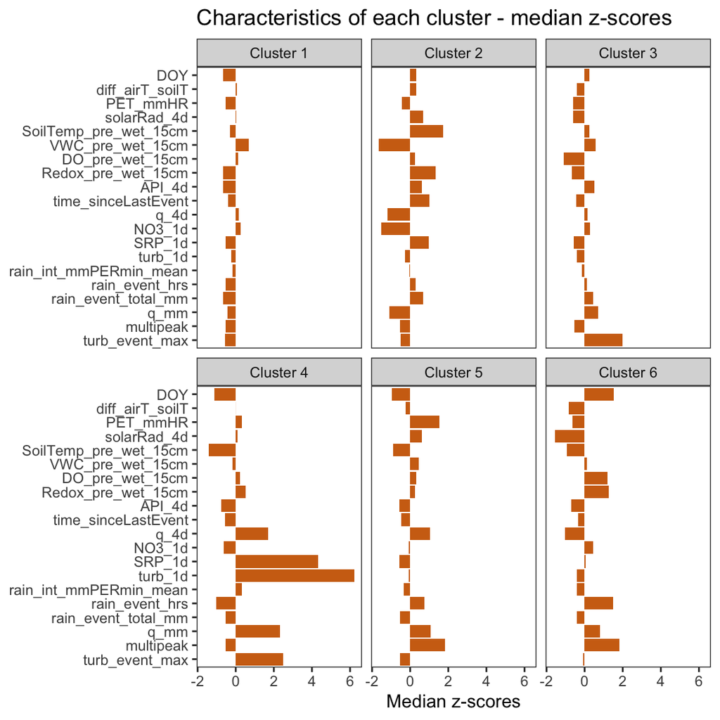

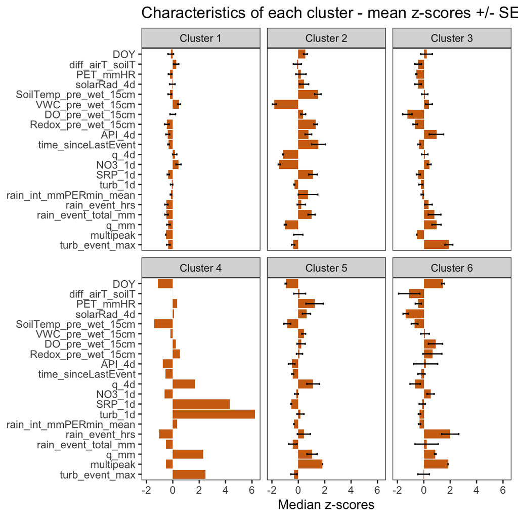

#### Examine how antecedent and event conditions converge to influence N & P flux regimes:

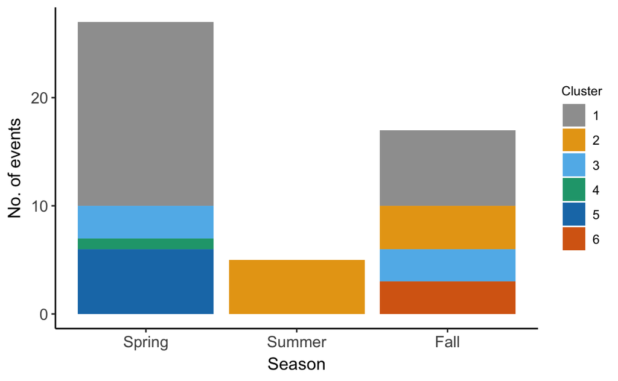

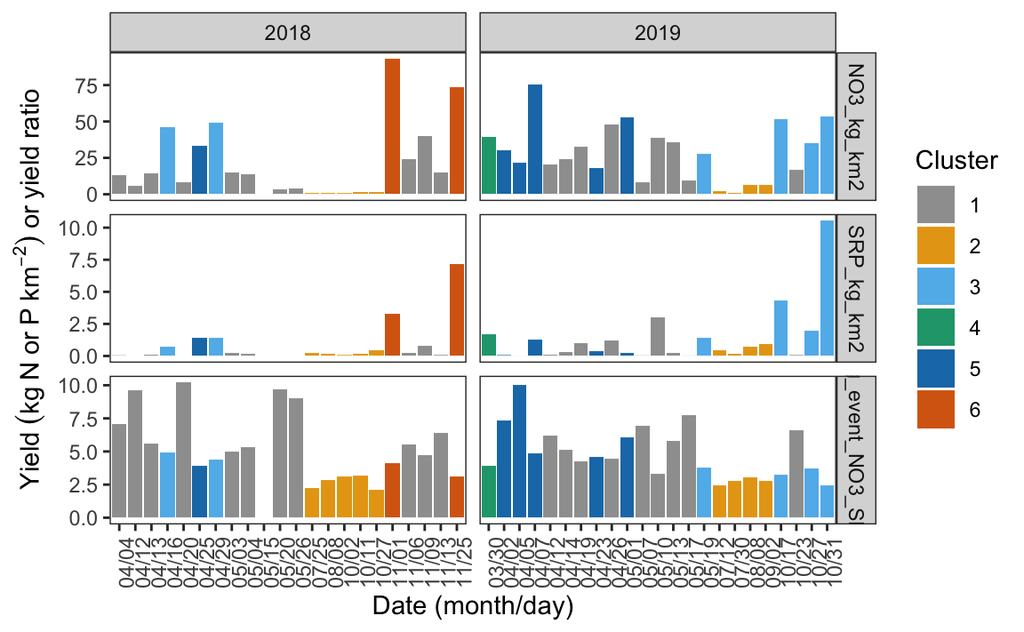

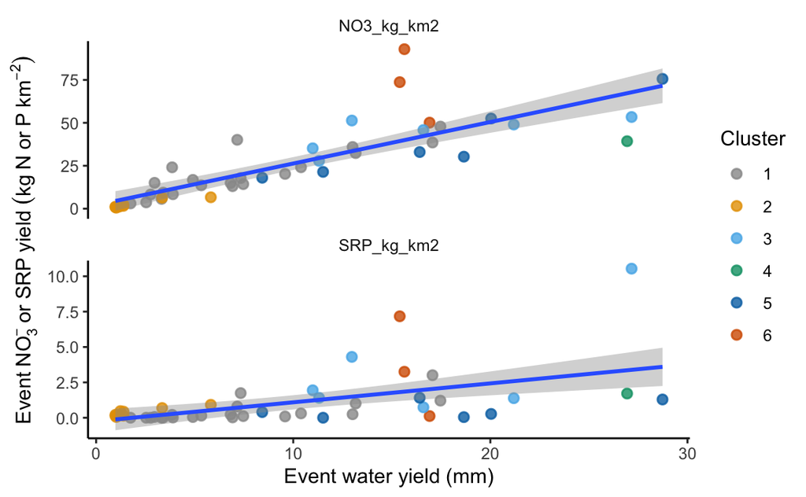

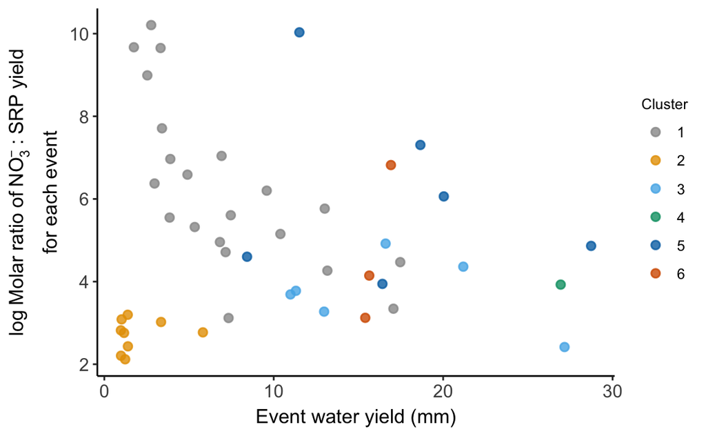

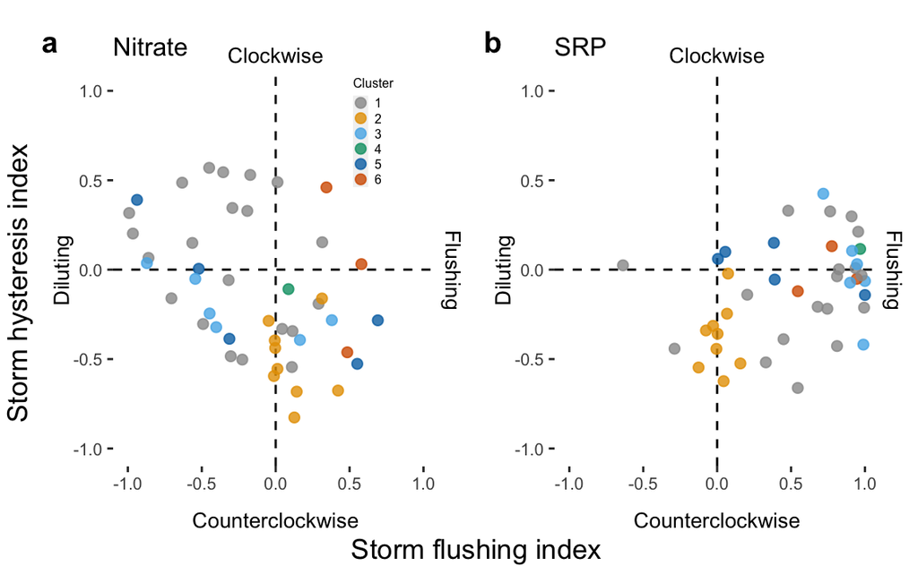